# Project: Sales Data Analysis

## Table of Contents:

- Introduction
- Data Cleaning
- Exploratory Data Analysis
- Conclusions

## Introduction:

> This report will investigate a sales representative and revenue dataset.

> This dataset includes the following properties:

```
      Date, SalesRep, Region, Product, Revenue, Color, Units, Revenue
```

> This investigation will focus on revenue generated, time periods of productivity, and most popular products sold.

> Over the course of this report, the following questions will be explored:
> - Question 1: What is the total and % revenue per region?
> - Question 2: What is the total revenue per year?
> - Question 3: For each Sales Rep, what are their total revenues per region?
> - Question 4: Which Sales Reps have the largest % of revenue for each of the regions?
> - Question 5: Which quarter has the highest earnings?
> - Question 6: What is the revenue per month for each year?
> - Question 7: What are the top 3 products sold?

```python
import pandas as pd
import matplotlib.pyplot as plt
%matplotlib inline
```

```python
df = pd.read_csv('salesRep_data.csv')
```

```python
df.head()
```

|  | Date | SalesRep | Region | Product | Color | Units | Revenue |
| --- | --- | --- | --- | --- | --- | --- | --- |
| 0 | 11/6/2015 | Julie | East | Sunshine | Blue | 4 | $78.80 |
| 1 | 11/7/2015 | Adam | West | Bellen | Clear | 4 | $123.00 |
| 2 | 11/7/2015 | Julie | East | Aspen | Clear | 1 | $26.00 |
| 3 | 11/7/2015 | Nabil | South | Quad | Clear | 2 | $69.00 |
| 4 | 11/7/2015 | Julie | South | Aspen | Blue | 2 | $51.00 |

## Data Cleaning:

```python
df.shape
```

```
(9971, 7)
```

```python
df.info()
```

```
<class 'pandas.core.frame.DataFrame'>
RangeIndex: 9971 entries, 0 to 9970
Data columns (total 7 columns):
Date        9971 non-null object
SalesRep    9971 non-null object
Region      9971 non-null object
Product     9971 non-null object
Color       9971 non-null object
Units       9971 non-null int64
Revenue     9971 non-null object
dtypes: int64(1), object(6)
memory usage: 545.4+ KB
```

### Convert the Date and Revenue columns to more useful datatypes.

```python
# Date converted from string to Date object.
df['Date'] = pd.to_datetime(df['Date'])
```

Several steps to convert the Revenue values to floats:

- Strip off the '$' sign
- Remove any existing commas (to avoid an error)

```python
# Strip off '$' signs
df.Revenue = df.Revenue.apply(lambda x: x.split('$')[1])
```

```python
df.Revenue
```

```
0        78.80
1       123.00
2        26.00
3        69.00
4        51.00
5        71.85
6       162.90
7        43.00
8       122.70
9       330.00
10       51.00
11       48.90
12       53.00
13       69.00
14      616.70
```

[output cut: 47 more lines]

```python
df.Revenue.sort_values()
```

```
3519    1,039.70
5681    1,066.30
7576    1,142.25
7829    1,187.80
8023    1,370.10
6276    1,370.10
8852    1,370.10
4544    1,446.05
7136    1,446.05
5478    1,522.00
7224    1,632.10
2074    1,749.85
8560    1,749.85
7234    1,825.80
2631    1,901.75
```

[output cut: 47 more lines]

```python
# Remove any commas
df.Revenue = df.Revenue.str.replace(',', '')
```

```python
# Convert to float datatype
df.Revenue = df.Revenue.astype(float)
```

```python
# Verify datatype changes
df.info()
```

```
<class 'pandas.core.frame.DataFrame'>
RangeIndex: 9971 entries, 0 to 9970
Data columns (total 7 columns):
Date        9971 non-null datetime64[ns]
SalesRep    9971 non-null object
Region      9971 non-null object
Product     9971 non-null object
Color       9971 non-null object
Units       9971 non-null int64
Revenue     9971 non-null float64
dtypes: datetime64[ns](1), float64(1), int64(1), object(4)
memory usage: 545.4+ KB
```

```python
# Copy to a clean dataframe
df_clean = df.copy()
```

```python
df_clean.head()
```

|  | Date | SalesRep | Region | Product | Color | Units | Revenue |
| --- | --- | --- | --- | --- | --- | --- | --- |
| 0 | 2015-11-06 | Julie | East | Sunshine | Blue | 4 | 78.8 |
| 1 | 2015-11-07 | Adam | West | Bellen | Clear | 4 | 123.0 |
| 2 | 2015-11-07 | Julie | East | Aspen | Clear | 1 | 26.0 |
| 3 | 2015-11-07 | Nabil | South | Quad | Clear | 2 | 69.0 |
| 4 | 2015-11-07 | Julie | South | Aspen | Blue | 2 | 51.0 |

### List the unique values for Sales Reps, Region, Products, and Colors.

```python
rep_list = list(df_clean.SalesRep.unique())
print("Sales Reps:", rep_list)
```

```
Sales Reps: ['Julie', 'Adam', 'Nabil', 'Jessica', 'Nicole', 'Mike']
```

```python
region_list = df_clean.Region.unique()
print("Region:", region_list)
```

```
Region: ['East' 'West' 'South']
```

```python
product_list = df_clean.Product.unique()
print("Products:", product_list)
```

```
Products: ['Sunshine' 'Bellen' 'Aspen' 'Quad' 'Carlota' 'Doublers' 'Sunbell']
```

```python
color_list = df_clean.Color.unique()
print("Color:", color_list)
```

```
Color: ['Blue' 'Clear' 'Red' 'Rainbow' 'Purple']
```

#### Add generated columns for the Month, Year, and Quarter.

```python
# Add a column for the month number values.
df_clean["Month_No"] = df_clean.Date.dt.month
```

```python
# Function converts month number to month name.
def month_num_2_name(num):
    month_dict = {
        1:"January", 2: "February", 3: "March",
        4: "April", 5: "May", 6: "June",
        7: "July", 8: "August", 9: "September",
        10: "October", 11: "November", 12: "December"
    }

    return month_dict[num]
```

```python
# Add a column for the month name values.
df_clean["Month"] = df_clean.Month_No.apply(lambda x: month_num_2_name(x))
```

```python
# Add a column for the year values
df_clean["Year"] = df_clean.Date.dt.year
```

```python
# Function will generate the proper quarter based on the observed month.
def generate_quarter(month):
    if month in ["January","February","March"]:
        return "Q1"
    elif month in ["April","May","June"]:
        return "Q2"
    elif month in ["July","August","September"]:
        return "Q3"
    elif month in ["October","November","December"]:
        return "Q4"
    else:
        return "Error: Name of month is not valid"
```

```python
df_clean["Quarter"] = df_clean.Month.apply(lambda month: generate_quarter(month))
```

## Exploratory Data Analysis:

```python
df_clean.info()
```

```
<class 'pandas.core.frame.DataFrame'>
RangeIndex: 9971 entries, 0 to 9970
Data columns (total 11 columns):
Date        9971 non-null datetime64[ns]
SalesRep    9971 non-null object
Region      9971 non-null object
Product     9971 non-null object
Color       9971 non-null object
Units       9971 non-null int64
Revenue     9971 non-null float64
Month_No    9971 non-null int64
Month       9971 non-null object
Year        9971 non-null int64
Quarter     9971 non-null object
dtypes: datetime64[ns](1), float64(1), int64(3), object(6)
memory usage: 857.0+ KB
```

```python
df_clean.head()
```

|  | Date | SalesRep | Region | Product | Color | Units | Revenue | Month_No | Month | Year | Quarter |
| --- | --- | --- | --- | --- | --- | --- | --- | --- | --- | --- | --- |
| 0 | 2015-11-06 | Julie | East | Sunshine | Blue | 4 | 78.8 | 11 | November | 2015 | Q4 |
| 1 | 2015-11-07 | Adam | West | Bellen | Clear | 4 | 123.0 | 11 | November | 2015 | Q4 |
| 2 | 2015-11-07 | Julie | East | Aspen | Clear | 1 | 26.0 | 11 | November | 2015 | Q4 |
| 3 | 2015-11-07 | Nabil | South | Quad | Clear | 2 | 69.0 | 11 | November | 2015 | Q4 |
| 4 | 2015-11-07 | Julie | South | Aspen | Blue | 2 | 51.0 | 11 | November | 2015 | Q4 |

```python
df_clean.loc[1000:1005,:]
```

|  | Date | SalesRep | Region | Product | Color | Units | Revenue | Month_No | Month | Year | Quarter |
| --- | --- | --- | --- | --- | --- | --- | --- | --- | --- | --- | --- |
| 1000 | 2016-06-10 | Jessica | West | Doublers | Red | 2 | 50.00 | 6 | June | 2016 | Q2 |
| 1001 | 2016-06-10 | Jessica | South | Aspen | Blue | 2 | 43.00 | 6 | June | 2016 | Q2 |
| 1002 | 2016-06-10 | Adam | South | Doublers | Red | 1 | 82.95 | 6 | June | 2016 | Q2 |
| 1003 | 2016-06-11 | Nabil | South | Bellen | Clear | 4 | 94.80 | 6 | June | 2016 | Q2 |
| 1004 | 2016-06-11 | Nicole | East | Sunshine | Red | 1 | 22.95 | 6 | June | 2016 | Q2 |
| 1005 | 2016-06-11 | Julie | East | Sunbell | Red | 2 | 58.00 | 6 | June | 2016 | Q2 |

```python
df_clean.tail()
```

|  | Date | SalesRep | Region | Product | Color | Units | Revenue | Month_No | Month | Year | Quarter |
| --- | --- | --- | --- | --- | --- | --- | --- | --- | --- | --- | --- |
| 9966 | 2017-11-05 | Nabil | South | Aspen | Clear | 2 | 51.00 | 11 | November | 2017 | Q4 |
| 9967 | 2017-11-05 | Julie | West | Aspen | Blue | 3 | 66.00 | 11 | November | 2017 | Q4 |
| 9968 | 2017-11-05 | Nicole | West | Bellen | Clear | 3 | 71.85 | 11 | November | 2017 | Q4 |
| 9969 | 2017-11-05 | Adam | West | Sunshine | Clear | 3 | 62.85 | 11 | November | 2017 | Q4 |
| 9970 | 2017-11-05 | Nabil | South | Bellen | Clear | 1 | 25.95 | 11 | November | 2017 | Q4 |

### Question 1: What is the total and % revenue per region?

```python
rev_per_region = df_clean.groupby('Region').Revenue.sum()
rev_per_region
```

```
Region
East     237876.79
South    263256.50
West     408037.58
Name: Revenue, dtype: float64
```

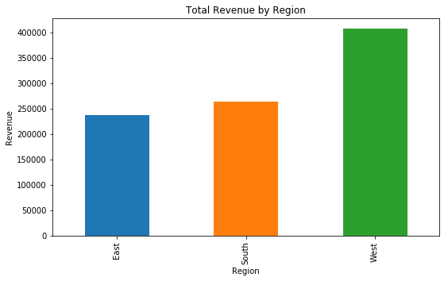

```python
# Plot data
plt.xlabel("Region")
plt.ylabel("Revenue")
plt.title("Total Revenue by Region")
plt.tight_layout()
rev_per_region.plot(kind='bar', figsize=[8,5]);
plt.savefig('total_rev_x_region.png', dpi=200)  # same copy of image
```

```python
# Percent revenue per region
prcnt_per_region = (rev_per_region / df_clean.Revenue.sum()) * 100
prcnt_per_region
```

```
Region
East     26.164146
South    28.955668
West     44.880186
Name: Revenue, dtype: float64
```

### Question 2: What is the total revenue per year?

```python
rev_per_year = df_clean.groupby('Year').Revenue.sum()
rev_per_year
```

```
Year
2015     24883.84
2016    444701.72
2017    439585.31
Name: Revenue, dtype: float64
```

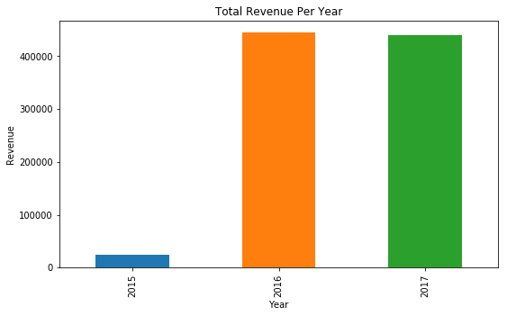

```python
# Plot data
plt.title("Total Revenue Per Year")
plt.xlabel("Year")
plt.ylabel("Revenue")
plt.tight_layout()
rev_per_year.plot(kind="bar", figsize=(8,5));
plt.savefig('total_rev_per_year.png', dpi=200)  # same copy of image
```

### Question 3: For each Sales Rep, what are their total revenues per region?

```python
rep_per_region = df_clean.groupby(["SalesRep","Region"]).Revenue.sum()
rep_per_region
```

```
SalesRep  Region
Adam      East      39822.81
          South     15982.89
          West      46909.90
Jessica   East      30218.32
          South     42985.99
          West      72291.97
Julie     East      49504.09
          South     63591.80
          West      91354.16
Mike      East      79578.02
          South     56576.29
          West      69423.47
Nabil     East      22789.03
          South     60656.10
          West      75459.35
Nicole    East      15964.52
          South     23463.43
          West      52598.73
Name: Revenue, dtype: float64
```

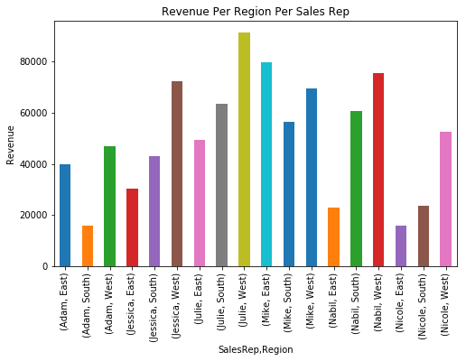

```python
# Quick plot of data
plt.xlabel("Sales Reps")
plt.ylabel("Revenue")
plt.title("Revenue Per Region Per Sales Rep")
rep_per_region.plot(kind="bar", figsize=(8,5));
```

#### Make dataframes and calculate total revenue for each Sales Rep.

```python
# Here is where I make the data for each subplot.
rep_list
```

```
['Julie', 'Adam', 'Nabil', 'Jessica', 'Nicole', 'Mike']
```

```python
df_Julie_rev = df_clean[df_clean['SalesRep'] == 'Julie'][["SalesRep","Region","Revenue"]]
df_Julie_rev.head()
```

|  | SalesRep | Region | Revenue |
| --- | --- | --- | --- |
| 0 | Julie | East | 78.8 |
| 2 | Julie | East | 26.0 |
| 4 | Julie | South | 51.0 |
| 7 | Julie | East | 43.0 |
| 8 | Julie | South | 122.7 |

```python
rev_Julie = df_Julie_rev.groupby(["Region"]).sum()
rev_Julie
```

| Region | Revenue |
| --- | --- |
| East | 49504.09 |
| South | 63591.80 |
| West | 91354.16 |

```python
# copy values in the dataframe to an array for charting
Julie_revs = rev_Julie.values[:,0]
```

```python
df_Adam_rev = df_clean[df_clean['SalesRep'] == 'Adam'][["SalesRep","Region","Revenue"]]
df_Adam_rev.head()
```

|  | SalesRep | Region | Revenue |
| --- | --- | --- | --- |
| 1 | Adam | West | 123.00 |
| 5 | Adam | South | 71.85 |
| 6 | Adam | West | 162.90 |
| 17 | Adam | East | 71.85 |
| 20 | Adam | West | 73.50 |

```python
rev_Adam = df_Adam_rev.groupby(["Region"]).sum()
rev_Adam
```

| Region | Revenue |
| --- | --- |
| East | 39822.81 |
| South | 15982.89 |
| West | 46909.90 |

```python
rev_Adam.values[:,0]
```

```
array([39822.81, 15982.89, 46909.9 ])
```

```python
Adam_revs = rev_Adam.values[:,0]
```

```python
df_Nabil_rev = df_clean[df_clean['SalesRep'] == 'Nabil'][["SalesRep","Region","Revenue"]]
df_Nabil_rev.head()
```

|  | SalesRep | Region | Revenue |
| --- | --- | --- | --- |
| 3 | Nabil | South | 69.00 |
| 14 | Nabil | South | 616.70 |
| 33 | Nabil | East | 99.00 |
| 46 | Nabil | West | 25.95 |
| 49 | Nabil | West | 82.95 |

```python
rev_Nabil = df_Nabil_rev.groupby(["Region"]).sum()
rev_Nabil
```

| Region | Revenue |
| --- | --- |
| East | 22789.03 |
| South | 60656.10 |
| West | 75459.35 |

```python
Nabil_revs = rev_Nabil.values[:,0]
```

```python
df_Jessica_rev = df_clean[df_clean['SalesRep'] == 'Jessica'][["SalesRep","Region","Revenue"]]
df_Jessica_rev.head()
```

|  | SalesRep | Region | Revenue |
| --- | --- | --- | --- |
| 9 | Jessica | South | 330.00 |
| 10 | Jessica | East | 51.00 |
| 30 | Jessica | South | 51.00 |
| 31 | Jessica | West | 75.00 |
| 38 | Jessica | West | 62.85 |

```python
rev_Jessica = df_Jessica_rev.groupby(["Region"]).sum()
rev_Jessica
```

| Region | Revenue |
| --- | --- |
| East | 30218.32 |
| South | 42985.99 |
| West | 72291.97 |

```python
Jessica_revs = rev_Jessica.values[:,0]
```

```python
df_Nicole_rev = df_clean[df_clean['SalesRep'] == 'Nicole'][["SalesRep","Region","Revenue"]]
df_Nicole_rev.head()
```

|  | SalesRep | Region | Revenue |
| --- | --- | --- | --- |
| 12 | Nicole | West | 53.0 |
| 13 | Nicole | East | 69.0 |
| 15 | Nicole | West | 78.0 |
| 22 | Nicole | South | 314.8 |
| 25 | Nicole | East | 50.0 |

```python
rev_Nicole = df_Nicole_rev.groupby(["Region"]).sum()
rev_Nicole
```

| Region | Revenue |
| --- | --- |
| East | 15964.52 |
| South | 23463.43 |
| West | 52598.73 |

```python
Nicole_revs = rev_Nicole.values[:,0]
```

```python
df_Mike_rev = df_clean[df_clean['SalesRep'] == 'Mike'][["SalesRep","Region","Revenue"]]
df_Mike_rev.head()
```

|  | SalesRep | Region | Revenue |
| --- | --- | --- | --- |
| 19 | Mike | East | 36.00 |
| 21 | Mike | East | 24.95 |
| 39 | Mike | South | 75.00 |
| 40 | Mike | East | 82.95 |
| 43 | Mike | West | 85.50 |

```python
rev_Mike = df_Mike_rev.groupby(["Region"]).sum()
rev_Mike
```

| Region | Revenue |
| --- | --- |
| East | 79578.02 |
| South | 56576.29 |
| West | 69423.47 |

```python
Mike_revs = rev_Mike.values[:,0]
```

### Alternate chart for Sales Rep: Revenue per Region

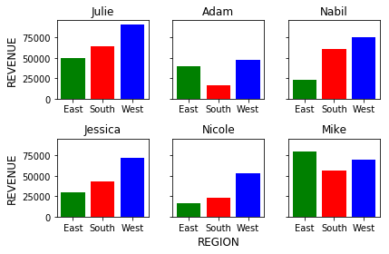

```python
fig_A, axes = plt.subplots(nrows=2, ncols=3, sharey=True)
# Row 1 axes labels
axes[0,0].set_title('Julie')
axes[0,0].set_ylabel('REVENUE', fontsize=12)
axes[0,1].set_title('Adam')
axes[0,2].set_title('Nabil')
# Row 2 axes labels
axes[1,0].set_title('Jessica')
axes[1,0].set_ylabel('REVENUE', fontsize=12)
axes[1,1].set_title('Nicole')
axes[1,2].set_title('Mike')
axes[1,1].set_xlabel("REGION", fontsize=12)
# options for all charts
regions = ['East', 'South', 'West']
colors = ['g', 'r', 'b']
plt.tight_layout()
# plot all data
axes[0,0].bar(regions, Julie_revs, color=colors)
axes[0,1].bar(regions, Adam_revs, color=colors)
axes[0,2].bar(regions, Nabil_revs, color=colors)
axes[1,0].bar(regions, Jessica_revs, color=colors)
axes[1,1].bar(regions, Nicole_revs, color=colors)
axes[1,2].bar(regions, Mike_revs, color=colors);
fig_A.savefig('all_salesRep_revenues.png', dpi=200)  # Save a copy of this image
```

### Question 4: Which Sales Reps have the largest % of revenue for each of the regions?

```python
rep_list
```

```
['Julie', 'Adam', 'Nabil', 'Jessica', 'Nicole', 'Mike']
```

```python
rep_per_region
```

```
SalesRep  Region
Adam      East      39822.81
          South     15982.89
          West      46909.90
Jessica   East      30218.32
          South     42985.99
          West      72291.97
Julie     East      49504.09
          South     63591.80
          West      91354.16
Mike      East      79578.02
          South     56576.29
          West      69423.47
Nabil     East      22789.03
          South     60656.10
          West      75459.35
Nicole    East      15964.52
          South     23463.43
          West      52598.73
Name: Revenue, dtype: float64
```

```python
rev_per_region
```

```
Region
East     237876.79
South    263256.50
West     408037.58
Name: Revenue, dtype: float64
```

Taking a different approach to making a dataframe info with SalesRep, Region, total revenues per region per rep, and the percent of the revenue for that region per rep.

Will make lists for each, then convert each of them to a Series, then to a combined dataframe.

```python
# Concatenate all SalesRep region total rev dataframes together.
df_SalesRep_regions = pd.concat([rev_Julie, rev_Adam, rev_Nabil, rev_Jessica, rev_Nicole, rev_Mike])
df_SalesRep_regions
```

| Region | Revenue |
| --- | --- |
| East | 49504.09 |
| South | 63591.80 |
| West | 91354.16 |
| East | 39822.81 |
| South | 15982.89 |
| West | 46909.90 |
| East | 22789.03 |
| South | 60656.10 |
| West | 75459.35 |
| East | 30218.32 |
| South | 42985.99 |
| West | 72291.97 |
| East | 15964.52 |
| South | 23463.43 |
| West | 52598.73 |
| East | 79578.02 |
| South | 56576.29 |
| West | 69423.47 |

```python
# The order of SalesRep in the df_SalesRep_regions: Julie, Adam, Nabil, Jessica, Nicole, Mike
# However, each name needs to be repeated 3 times in order in the generated list.
# Note, this sales rep order from make from the previous rep_list from the beginning of this notebook.
rep_list
```

```
['Julie', 'Adam', 'Nabil', 'Jessica', 'Nicole', 'Mike']
```

```python
# Make a list with each name repeated 3 times
rep_list_3x = []
for name in rep_list:
    for round in range(3):
        rep_list_3x.append(name)

rep_list_3x
```

```
['Julie',
 'Julie',
 'Julie',
 'Adam',
 'Adam',
 'Adam',
 'Nabil',
 'Nabil',
 'Nabil',
 'Jessica',
 'Jessica',
 'Jessica',
 'Nicole',
 'Nicole',
 'Nicole',
 'Mike',
 'Mike',
 'Mike']
```

```python
# Make sales rep list into a Series
rep_list_3x_series = pd.Series(rep_list_3x)
rep_list_3x_series
```

```
0       Julie
1       Julie
2       Julie
3        Adam
4        Adam
5        Adam
6       Nabil
7       Nabil
8       Nabil
9     Jessica
10    Jessica
11    Jessica
12     Nicole
13     Nicole
14     Nicole
15       Mike
16       Mike
17       Mike
dtype: object
```

```python
# Make list from the index of df_SalesRep_regions
rep_region_list = list(df_SalesRep_regions.index)
rep_region_list
```

```
['East',
 'South',
 'West',
 'East',
 'South',
 'West',
 'East',
 'South',
 'West',
 'East',
 'South',
 'West',
 'East',
 'South',
 'West',
 'East',
 'South',
 'West']
```

```python
rep_region_series = pd.Series(rep_region_list)
rep_region_series
```

```
0      East
1     South
2      West
3      East
4     South
5      West
6      East
7     South
8      West
9      East
10    South
11     West
12     East
13    South
14     West
15     East
16    South
17     West
dtype: object
```

```python
# Make a list from the region total revenues per sales rep.
rep_rev_per_region = list(df_SalesRep_regions.Revenue)
rep_rev_per_region
```

```
[49504.09000000002,
 63591.79999999997,
 91354.1599999998,
 39822.80999999999,
 15982.890000000005,
 46909.89999999999,
 22789.029999999995,
 60656.099999999984,
 75459.34999999987,
 30218.320000000014,
 42985.99000000002,
 72291.96999999993,
 15964.519999999995,
 23463.430000000008,
 52598.729999999996,
 79578.01999999992,
 56576.28999999996,
 69423.46999999994]
```

```python
# Here we will format our list of revenues to have just 2 decimal digits.
rep_rev_per_region_formatted = [float('%.2f' %num) for num in rep_rev_per_region]
rep_rev_per_region_formatted
```

```
[49504.09,
 63591.8,
 91354.16,
 39822.81,
 15982.89,
 46909.9,
 22789.03,
 60656.1,
 75459.35,
 30218.32,
 42985.99,
 72291.97,
 15964.52,
 23463.43,
 52598.73,
 79578.02,
 56576.29,
 69423.47]
```

```python
rep_rev_reg_series = pd.Series(rep_rev_per_region_formatted)
rep_rev_reg_series
```

```
0     49504.09
1     63591.80
2     91354.16
3     39822.81
4     15982.89
5     46909.90
6     22789.03
7     60656.10
8     75459.35
9     30218.32
10    42985.99
11    72291.97
12    15964.52
13    23463.43
14    52598.73
15    79578.02
16    56576.29
17    69423.47
dtype: float64
```

```python
# Make a list of percents for the Sales Rep revenues in the order within the df_Sales_regions
# The following for loop calculates the percent for each region per Sales rep.

percent_list = []
region_dict = {'East': 0, 'South': 1, 'West': 2}
count = 0
for rev in df_SalesRep_regions.Revenue:
    if count == region_dict['East']:
        region = count
    elif count == region_dict['South']:
        region = count
    else:
        region = count

    percent = rev/rev_per_region[region]  # rev_per_region[region] is the total revenue for that region
    percent_list.append(percent)

    count += 1
    if count > 2:
        count = 0

percent_list
```

```
[0.20810811344814203,
 0.2415583280944623,
 0.2238866331870681,
 0.1674093971084773,
 0.06071223312624747,
 0.11496465595154141,
 0.0958018224476626,
 0.23040684655459537,
 0.1849323535346896,
 0.1270334949450088,
 0.16328557889358825,
 0.17716988224466793,
 0.0671125585644566,
 0.0891276378740884,
 0.12890658257506457,
 0.3345346134862492,
 0.21490937545701558,
 0.17013989250695807]
```

```python
percent_series = pd.Series(percent_list)
percent_series
```

```
0     0.208108
1     0.241558
2     0.223887
3     0.167409
4     0.060712
5     0.114965
6     0.095802
7     0.230407
8     0.184932
9     0.127033
10    0.163286
11    0.177170
12    0.067113
13    0.089128
14    0.128907
15    0.334535
16    0.214909
17    0.170140
dtype: float64
```